# airbnb

## Imports

```python
import matplotlib.pyplot as plt
import numpy as np
import pandas as pd
import shap
```

```python
from sklearn.model_selection import train_test_split
from sklearn.compose import make_column_transformer
from sklearn.pipeline import make_pipeline
from sklearn.preprocessing import StandardScaler
from sklearn.preprocessing import OneHotEncoder
from sklearn.preprocessing import OrdinalEncoder
from sklearn.impute import SimpleImputer
from sklearn.preprocessing import FunctionTransformer
from sklearn.feature_extraction.text import CountVectorizer
from sklearn.dummy import DummyRegressor
from sklearn.linear_model import Ridge
from sklearn.model_selection import cross_validate
from sklearn.model_selection import GridSearchCV
from sklearn.preprocessing import KBinsDiscretizer
from sklearn.tree import DecisionTreeRegressor
from sklearn.svm import SVC
from sklearn.ensemble import RandomForestRegressor
from sklearn.neighbors import KNeighborsRegressor
from sklearn.feature_selection import RFECV
from scipy.stats import randint
from scipy.stats import uniform
from sklearn.model_selection import RandomizedSearchCV
from sklearn.metrics import mean_squared_error
```

1. The Prediction Problem
2. Data splitting
3. EDA
4. Feature engineering
5. Preprocessing and transformations
6. Baseline model
7. Linear models
8. Different models
9. Feature selection
10. Hyperparameter optimization
11. Interpretation and feature importances
12. Final results
13. Summary of the results

## 1. The Prediction Problem

In this project I'll be exploring a [dataset](https://insideairbnb.com/get-the-data) of Vancouver Airbnb listings from 2023. Specifically, I will create a customer satisfaction regression model to try to predict a listing's `review_scores_rating`, as a proxy for the popularity of the listing. Airbnb could use this sort of model to recommend new listings with high potential for customer satisfaction to site browsers. Furthermore, this model could identify the factors which are most important in predicting high ratings, which hosts can then use to improve their own listings.

> The documentation of the dataset can be found [here](https://docs.google.com/spreadsheets/d/1iWCNJcSutYqpULSQHlNyGInUvHg2BoUGoNRIGa6Szc4/edit#gid=1322284596).

```python
airbnb_df = pd.read_csv("data/listings.csv")
airbnb_df.head()
```

|  | id | listing_url | scrape_id | last_scraped | source | name | description | neighborhood_overview | picture_url | host_id | ... | review_scores_communication | review_scores_location | review_scores_value | license | instant_bookable | calculated_host_listings_count | calculated_host_listings_count_entire_homes | calculated_host_listings_count_private_rooms | calculated_host_listings_count_shared_rooms | reviews_per_month |
| --- | --- | --- | --- | --- | --- | --- | --- | --- | --- | --- | --- | --- | --- | --- | --- | --- | --- | --- | --- | --- | --- |
| 0 | 13188 | https://www.airbnb.com/rooms/13188 | 20231213195611 | 2023-12-14 | city scrape | Rental unit in Vancouver · ★4.84 · Studio · 2 ... | NaN | The uber hip Main street area is a short walk ... | https://a0.muscache.com/pictures/8408188/e1af6... | 51466 | ... | 4.92 | 4.88 | 4.80 | 23-156488 | t | 1 | 1 | 0 | 0 | 1.68 |
| 1 | 13221 | https://www.airbnb.com/rooms/13221 | 20231213195611 | 2023-12-14 | city scrape | Rental unit in Vancouver · ★4.73 · 1 bedroom ·... | NaN | The Mount Pleasant neighbourhood is *the* plac... | https://a0.muscache.com/pictures/miso/Hosting-... | 51634 | ... | 4.80 | 4.87 | 4.60 | NaN | f | 1 | 1 | 0 | 0 | 0.15 |
| 2 | 13358 | https://www.airbnb.com/rooms/13358 | 20231213195611 | 2023-12-14 | city scrape | Condo in Vancouver · ★4.68 · 1 bedroom · 1 bed... | NaN | 2 blocks away from the shopping area of Robson... | https://a0.muscache.com/pictures/miso/Hosting-... | 52116 | ... | 4.79 | 4.91 | 4.65 | 22-311727 | f | 1 | 1 | 0 | 0 | 3.00 |
| 3 | 13490 | https://www.airbnb.com/rooms/13490 | 20231213195611 | 2023-12-13 | city scrape | Rental unit in Vancouver · ★4.93 · 1 bedroom ·... | NaN | In the heart of Vancouver, this apartment has ... | https://a0.muscache.com/pictures/73394727/79d5... | 52467 | ... | 4.97 | 4.79 | 4.89 | NaN | f | 1 | 1 | 0 | 0 | 0.66 |
| 4 | 14267 | https://www.airbnb.com/rooms/14267 | 20231213195611 | 2023-12-13 | city scrape | Home in Vancouver · ★4.76 · 1 bedroom · 2 beds... | NaN | We live in the centre of the city of Vancouver... | https://a0.muscache.com/pictures/3646de9b-934e... | 56030 | ... | 4.68 | 4.77 | 4.71 | 21-156500 | t | 1 | 1 | 0 | 0 | 0.21 |

5 rows × 75 columns

Upon initial review of the dataset, it seems like a few of the features were extracted from `name`, but this extraction was incomplete. For example, there is a column for `beds` that matches the information from the `name` column, yet `bedrooms` is empty, despite the data also being available in the `name` column. Let's start by extracting the rest of the missing information so I can reduce the data size from dropping the redundant `name` column. Additionally, I will convert (and rename) `bathrooms_text` to be a numeric feature instead.

I also noticed that `price` is formatted as a string starting with $, and `host_acceptance_rate` and `host_response_rate` are formatted as strings ending with %. I will remove these as well and convert them to numeric types to make analysis a bit easier.

```python
import re

def extract_bedroom_number(string):
    """
    Assuming the word 'bedroom' exists anywhere in the string, extract the number
    before it; otherwise return nothing

    The regular expression pattern:
    \d+ matches one or more digits
    (?:\.\d+)? optionally matches a decimal point followed by one or more digits
    \s*bedroom matches zero or more whitespace characters followed by 'bedroom'
    """
    match = re.search(r'(\d+(?:\.\d+)?)\s*bedroom', string)
    if match:
        return float(match.group(1))
    else:
        return None

def extract_bathroom_number(string):
    """
    Extract the leading character from the bathroom_text string and return this
    remaining number of bathrooms as a float, or None if missing value
    """
    if pd.isna(string):
        return None

    match = re.match(r'\d+\.\d+|\d+', string)
    if match:
        return float(match.group())
    return None

def convert_price(price):
    """
    Remove the $ from a given price and return the remaining number as a float
    """
    if pd.notna(price):
        if isinstance(price, str):
            if price.startswith('$'):
                price = price[1:]
            # Remove any commas (for cases like $1,000)
            price = price.replace(',', '')
            return float(price)
    return price

def convert_percents(string):
    """
    Remove the % from the end of a string and return the remaining number as a float
    """
    if pd.notna(string):
        if isinstance(string, str):
            string = string.replace(',', '')
            return float(string[:-1])
    return string
```

```python
# Create new bedrooms feature
airbnb_df['bedrooms'] = airbnb_df['name'].apply(extract_bedroom_number)

# Update baths feature
airbnb_df['baths'] = airbnb_df['bathrooms_text'].apply(extract_bathroom_number)

# Update price feature
airbnb_df['price'] = airbnb_df['price'].apply(convert_price)

# Update host response/acceptance rates
airbnb_df['host_response_rate'] = airbnb_df['host_response_rate'].apply(convert_percents)
airbnb_df['host_acceptance_rate'] = airbnb_df['host_acceptance_rate'].apply(convert_percents)
```

I also noticed that the target has missing values. Because I don't want to introduce bias into my model through imputation, I will be dropping all rows with a missing target. For a similar reason, I will also be dropping rows with missing values that can't be naturally estimated in a few other features, to ensure consistency in my train and validation sets.

```python
df_cleaned = airbnb_df.dropna(subset=['review_scores_rating', 'host_is_superhost', 'price', 'first_review', 'last_review',
                                     'review_scores_checkin', 'review_scores_location', 'review_scores_value'])
```

```python
df_cleaned[['bedrooms', 'baths', 'price', 'host_response_rate', 'host_acceptance_rate']]
```

|  | bedrooms | baths | price | host_response_rate | host_acceptance_rate |
| --- | --- | --- | --- | --- | --- |
| 0 | NaN | 1.0 | 150.0 | 100.0 | 100.0 |
| 1 | 1.0 | 1.0 | 120.0 | 100.0 | 0.0 |
| 2 | 1.0 | 1.0 | 165.0 | 100.0 | 99.0 |
| 3 | 1.0 | 1.0 | 150.0 | 100.0 | 97.0 |
| 4 | 1.0 | 1.0 | 150.0 | 100.0 | 0.0 |
| ... | ... | ... | ... | ... | ... |
| 6609 | 2.0 | 1.0 | 109.0 | 100.0 | 100.0 |
| 6611 | 1.0 | 1.0 | 90.0 | 100.0 | 100.0 |
| 6614 | 1.0 | 1.5 | 100.0 | 100.0 | 100.0 |
| 6627 | 2.0 | 2.0 | 282.0 | 100.0 | 100.0 |
| 6641 | 1.0 | 1.0 | 140.0 | 100.0 | 100.0 |

4870 rows × 5 columns

## 2. Data splitting

I am splitting the data into train (70%) and test (30%) portions with `random_state=123`.

```python
X = df_cleaned.drop(columns=["review_scores_rating"])
y = df_cleaned["review_scores_rating"]

X_train, X_test, y_train, y_test = train_test_split(
    X, y, test_size=0.3, random_state=123)
```

## 3. EDA

As the model aims to predict popularity of a listing, we can immediately pick out irrelevant features that can be dropped through an intuitive understanding of the problem. This includes unique identifiers, non-informative metadata, empty columns, and redundant, less informative features.

```python
X_train.info()
```

```
<class 'pandas.core.frame.DataFrame'>
Index: 3409 entries, 4097 to 4653
Data columns (total 75 columns):
 #   Column                                        Non-Null Count  Dtype
---  ------                                        --------------  -----
 0   id                                            3409 non-null   int64
 1   listing_url                                   3409 non-null   object
 2   scrape_id                                     3409 non-null   int64
 3   last_scraped                                  3409 non-null   object
 4   source                                        3409 non-null   object
 5   name                                          3409 non-null   object
 6   description                                   0 non-null      float64
 7   neighborhood_overview                         2416 non-null   object
 8   picture_url                                   3409 non-null   object
 9   host_id                                       3409 non-null   int64
```

[output cut: 67 more lines]

From above, we can see that we have a few columns with missing values. Even though I've already done some preliminary data cleaning regarding missing values, the remaining issues can be resolved in the preprocessor object.

```python
# Summary statistics for numeric features
X_train.describe()
```

|  | id | scrape_id | description | host_id | host_response_rate | host_acceptance_rate | host_listings_count | host_total_listings_count | neighbourhood_group_cleansed | latitude | ... | review_scores_checkin | review_scores_communication | review_scores_location | review_scores_value | calculated_host_listings_count | calculated_host_listings_count_entire_homes | calculated_host_listings_count_private_rooms | calculated_host_listings_count_shared_rooms | reviews_per_month | baths |
| --- | --- | --- | --- | --- | --- | --- | --- | --- | --- | --- | --- | --- | --- | --- | --- | --- | --- | --- | --- | --- | --- |
| count | 3.409000e+03 | 3.409000e+03 | 0.0 | 3.409000e+03 | 3072.000000 | 3254.000000 | 3409.000000 | 3409.000000 | 0.0 | 3409.000000 | ... | 3409.000000 | 3409.000000 | 3409.000000 | 3409.000000 | 3409.000000 | 3409.00000 | 3409.000000 | 3409.000000 | 3409.000000 | 3402.000000 |
| mean | 4.128757e+17 | 2.023121e+13 | NaN | 1.928403e+08 | 97.741211 | 91.418562 | 10.959226 | 16.860076 | NaN | 49.262465 | ... | 4.838706 | 4.860722 | 4.808877 | 4.652593 | 7.414784 | 6.61279 | 0.783221 | 0.017894 | 1.978489 | 1.327014 |
| std | 4.189233e+17 | 0.000000e+00 | NaN | 1.810600e+08 | 9.853027 | 17.614375 | 37.965543 | 53.429587 | NaN | 0.021144 | ... | 0.339715 | 0.334121 | 0.301852 | 0.417417 | 21.360858 | 21.40674 | 2.283900 | 0.201162 | 1.964283 | 0.627683 |
| min | 1.318800e+04 | 2.023121e+13 | NaN | 4.662000e+03 | 0.000000 | 0.000000 | 1.000000 | 1.000000 | NaN | 49.202960 | ... | 1.000000 | 1.000000 | 1.000000 | 1.000000 | 1.000000 | 0.00000 | 0.000000 | 0.000000 | 0.010000 | 0.000000 |
| 25% | 3.361072e+07 | 2.023121e+13 | NaN | 2.507482e+07 | 100.000000 | 92.000000 | 1.000000 | 1.000000 | NaN | 49.249630 | ... | 4.810000 | 4.860000 | 4.750000 | 4.590000 | 1.000000 | 1.00000 | 0.000000 | 0.000000 | 0.390000 | 1.000000 |
| 50% | 5.549512e+17 | 2.023121e+13 | NaN | 1.346010e+08 | 100.000000 | 99.000000 | 2.000000 | 3.000000 | NaN | 49.269104 | ... | 4.930000 | 4.950000 | 4.890000 | 4.750000 | 1.000000 | 1.00000 | 0.000000 | 0.000000 | 1.250000 | 1.000000 |
| 75% | 8.394611e+17 | 2.023121e+13 | NaN | 3.498042e+08 | 100.000000 | 100.000000 | 5.000000 | 8.000000 | NaN | 49.279007 | ... | 5.000000 | 5.000000 | 5.000000 | 4.860000 | 4.000000 | 2.00000 | 0.000000 | 0.000000 | 3.100000 | 1.500000 |
| max | 1.038818e+18 | 2.023121e+13 | NaN | 5.493638e+08 | 100.000000 | 100.000000 | 466.000000 | 1037.000000 | NaN | 49.294360 | ... | 5.000000 | 5.000000 | 5.000000 | 5.000000 | 134.000000 | 134.00000 | 18.000000 | 3.000000 | 15.190000 | 6.500000 |

8 rows × 44 columns

The numeric features in this dataset vary quite a bit and are reported in different measurements (%, $, #). I will scale most of them using a StandardScaler.

However, 2 particular numeric features stand out to me that may be better suited to a different method. Even though we have a feature for neighbourhood groups, `latitude` and `longitude` may be useful in revealing additional patterns about how location affects the reviews a listing receives and thus popularity. For example, maybe 2 neighbourhoods that are geographically closer north get more reviews than southern listings, or maybe there's a cluster of area that's popular but not encapsulated by the neighbourhood groups. By binning these features into a range of values instead of using their floating point representation, perhaps we can obtain more informative insights.

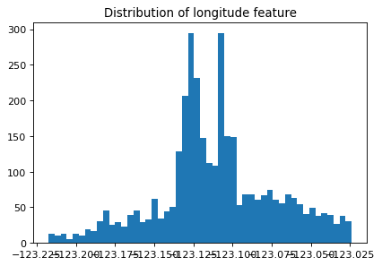

```python
plt.figure(figsize=(6, 4), dpi=80)
plt.hist(X_train["longitude"], bins=50)
plt.title("Distribution of longitude feature");
```

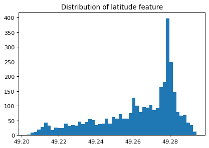

```python
plt.figure(figsize=(6, 4), dpi=80)
plt.hist(X_train["latitude"], bins=50)
plt.title("Distribution of latitude feature");
```

Other unique features in the dataset include raw text features `neighborhood_overview` and `host_about`. I will definitely address these when creating the model, but for now I thought it might be interesting to create a simple word cloud to get a quick glimpse into what the most popular vocabulary words are across all the listing descriptions.

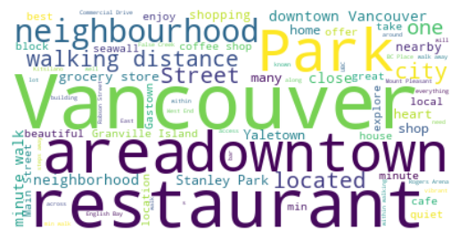

```python
from wordcloud import WordCloud

def remove_html_tags(text):
    """
    Remove HTML tags from a string
    """
    clean = re.compile('<.*?>')
    return re.sub(clean, '', text)

# Join all review texts into a single string, cleaning HTML tags in the process
overview = ' '.join(remove_html_tags(overview) for overview in X_train.dropna(subset=['neighborhood_overview'])['neighborhood_overview'])

wordcloud = WordCloud(background_color='white').generate(overview)
plt.imshow(wordcloud, interpolation='bilinear')
plt.axis('off')
plt.show()
```

Finally, there are quite a few overlapping features. It might be beneficial to only choose the most informative ones to keep, in order to reduce data multicollinearity.

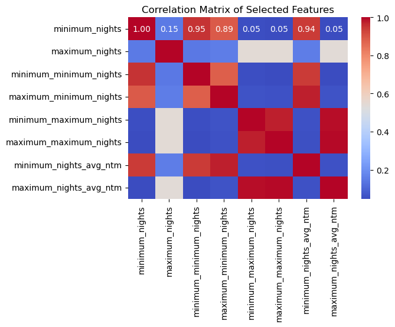

```python
import seaborn as sns

corr_matrix = X_train[['minimum_nights', 'maximum_nights', 'minimum_minimum_nights', 'maximum_minimum_nights',
                       'minimum_maximum_nights', 'maximum_maximum_nights', 'minimum_nights_avg_ntm',
                       'maximum_nights_avg_ntm',]].corr()

# Plot the heatmap
plt.figure(figsize=(6, 4))
sns.heatmap(corr_matrix, annot=True, fmt=".2f", cmap='coolwarm')
plt.title('Correlation Matrix of Selected Features')
plt.show()
```

## 4. Feature engineering

In the dataset, there are a few time series features that I don't think on their own will be too informative on the prediction problem. My goal is to identify general patterns that popular listings have in common; the exact date that a first review was posted or when a host created their account shouldn't have any direct impact on popularity and would just add complexity to the model.

Instead, these time series features can be used to create more informative/relevant features. One example that may be insightful to engineer is `days_to_first_review`, which subtracts the date that the listing received its first review (`first_review`) from the date the listing was created to calculate how long it took a listing to get its first review. Since we don't have the exact date that the listing was created, I will use the date that the host created their profile (`host_since`) as a close substitute. This new feature could potentially indicate market demand, i.e. if a particular neighbourhood tends to receive reviews faster, it's likely to be a more popular tourist location. Similarly, a short turnaround time to a first review can also reveal patterns in the hosts' listings, potentially suggesting effective strategies.

```python
# Add new feature to train data
X_train['host_since'] = pd.to_datetime(X_train['host_since'])
X_train['first_review'] = pd.to_datetime(X_train['first_review'])
X_train['days_to_first_review'] = (X_train['first_review'] - X_train['host_since']).dt.days

# Add new feature to test data
X_test['host_since'] = pd.to_datetime(X_test['host_since'])
X_test['first_review'] = pd.to_datetime(X_test['first_review'])
X_test['days_to_first_review'] = (X_test['first_review'] - X_test['host_since']).dt.days
```

The dataset I'm using was last updated on December 13, 2023. In contrast to the feature created above, I will also add a new feature `last_given_review`, which subtracts the date that the last review was given (`last_review`) from the date the dataset was last updated, to calculate in relative terms how many days ago the last review was posted. While the most recent review may not necessarily have been positive, this additional feature shows engagement (we can hypothesize that listings with a shorter gap since their most recent review are more popular).

```python
last_update_date = pd.Timestamp('2023-12-13')

# Add new feature to train data
X_train['last_review'] = pd.to_datetime(X_train['last_review'])
X_train['days_since_last_review'] = (last_update_date - X_train['last_review']).dt.days

# Add new feature to test data
X_test['last_review'] = pd.to_datetime(X_test['last_review'])
X_test['days_since_last_review'] = (last_update_date - X_test['last_review']).dt.days
```

```python
# Add new feature to train data
X_train['first_review'] = pd.to_datetime(X_train['first_review'])
X_train['last_review'] = pd.to_datetime(X_train['last_review'])

# Compute the review frequency
X_train['review_frequency'] = (X_train['last_review'] - X_train['first_review']).dt.days / X_train['number_of_reviews']

# Replace infinite and NaN results when number of reviews is zero.
X_train['review_frequency'].replace([pd.NA, float('inf'), -float('inf')], None, inplace=True)

# Add new feature to test data
X_test['first_review'] = pd.to_datetime(X_test['first_review'])
X_test['last_review'] = pd.to_datetime(X_test['last_review'])
X_test['review_frequency'] = (X_test['last_review'] - X_test['first_review']).dt.days / X_test['number_of_reviews']
X_test['review_frequency'].replace([pd.NA, float('inf'), -float('inf')], None, inplace=True)
```

## 5. Preprocessing and transformations

Finally, it's time to put everything together! In the initial dataset, there are columns with missing values, all different variable types, and potential feature engineering opportunities. Below, I've outlined the transformations and actions I want to perform to get my data ready for a model:

1. Feature Engineering
2. Convert Relevant Data Types
3. Impute and Scale Numeric Features
4. Encode Binary, Ordinal, and then regular Categorical Features
5. Handle Text Data
6. Drop Unnecessary Features

### **Step 1: Feature Engineering**

The feature engineering opportunities have been outlined in the previous sections. Below are the remaining features I will incorporate in my preprocessor.

```python
discretization_feats = ['latitude', 'longitude']
```

### **Step 2: Convert Relevant Data Types**

This dataset has a special feature: `host_id`. Although it is represented numerically, it should actually be treated as a categorical feature because it serves as a unique identifier for hosts, who may have multiple listings. I will convert this feature to be of type string to fit in with the other categorical features that will be one-hot encoded. With this feature, we can explore and compare listings between top hosts and potentially draw patterns there.

```python
X_train['host_id'] = X_train['host_id'].astype(str)
X_test['host_id'] = X_test['host_id'].astype(str)
```

### **Step 3: Impute and Scale Numeric Features**

As mentioned in the EDA section, there are many numeric features, all with different ranges. Below are the features I've chosen to keep. Some numeric features (`host_response_rate`, `host_acceptance_rate`, `bedrooms`, `beds`, `baths`) have a small amount of missing values. Since the rest of the rows could still contain informative data, I am choosing to indicate missing values as -1.

```python
numeric_feats = ['host_response_rate', 'host_listings_count', 'accommodates', 'minimum_nights', 'maximum_nights',
                 'minimum_nights_avg_ntm', 'maximum_nights_avg_ntm', 'availability_365', 'number_of_reviews', 'number_of_reviews_ltm',
                 'number_of_reviews_l30d', 'review_scores_accuracy', 'review_scores_cleanliness', 'review_scores_checkin',
                 'review_scores_communication', 'review_scores_location', 'review_scores_value', 'reviews_per_month',
                 'calculated_host_listings_count', 'bedrooms', 'beds', 'baths', 'days_to_first_review',
                 'days_since_last_review', 'review_frequency']
```

### **Step 4: Encode Binary, Ordinal, and then regular Categorical Features**

Of the categorical features, I noticed a few features that can be represented differently. By identifying features with binary or ordinal values, the model's computational efficiency can be improved. Only one categorical feature contains missing values: `host_response_time`. Since there are a few hundred missing values in this feature and the original dataset is not that big, I want to avoid deleting rows. Instead, I will convert NaNs to a string "Unknown", since again, the rest of the rows should still be highly informative.

```python
binary_feats = ['host_is_superhost', 'instant_bookable', 'host_has_profile_pic', 'host_identity_verified']
ordinal_feats = ['host_response_time']
ordinal_cats = ['within an hour', 'within a few hours', 'within a day', 'a few days or more', 'unknown']
categorical_feats = ['host_id', 'neighbourhood_cleansed', 'property_type', 'room_type']
```

### **Step 5: Handle Text Data**

This dataset contains 2 raw text features: `neighborhood_overview` and `host_about`. `neighborhood_overview` refers to the host's description of the listing's neighbourhood, while `host_about` refers to the host's self-written biography. Because both texts are written by the host, I will assume that these descriptions are generally intended to emanate a positive sentiment. Another more informative method to investigate the text might be to extract bag-of-words features to identify popular words used in descriptions.

```python
def reshape_for_countvectorizer(X):
    # Flatten the df array to from 2D to 1D (CountVectorizer can only take 1D arrays)
    return X.squeeze()
```

```python
nbrd_text_feat = ['neighborhood_overview']
host_text_feat = ['host_about']
```

### **Step 6: Drop Unnecessary Features**

The final drop list, which encompasses the rest of the features not accounted for in the steps before, can be found below.

```python
drop_feats = ['name', 'id', 'listing_url', 'scrape_id', 'last_scraped', 'source', 'picture_url', 'host_url',
              'host_name', 'host_thumbnail_url', 'host_picture_url', 'calendar_last_scraped', 'description',
              'neighbourhood_group_cleansed', 'bathrooms', 'calendar_updated', 'license', 'host_location',
              'host_neighbourhood', 'host_listings_count', 'host_total_listings_count', 'host_verifications',
              'neighbourhood', 'bathrooms_text', 'amenities', 'has_availability', 'first_review', 'last_review',
              'host_since', 'minimum_minimum_nights', 'maximum_minimum_nights', 'minimum_maximum_nights',
              'maximum_maximum_nights', 'availability_30', 'availability_60', 'availability_90',
              'calculated_host_listings_count_entire_homes', 'calculated_host_listings_count_private_rooms',
              'calculated_host_listings_count_shared_rooms']
```

With all the transformations specified, it's time to put it together in a pipeline!

```python
# Final preprocessor object

preprocessor = make_column_transformer(
    (KBinsDiscretizer(n_bins=20, encode="onehot"), discretization_feats),
    (make_pipeline(
        (SimpleImputer(strategy='constant', fill_value=-1)),
        StandardScaler()), numeric_feats),
    (OneHotEncoder(drop="if_binary", dtype=int, sparse_output=False), binary_feats),
    (make_pipeline(
        SimpleImputer(strategy='constant', fill_value='unknown'),
        OrdinalEncoder(categories=[ordinal_cats])), ordinal_feats),
    (make_pipeline(
        SimpleImputer(strategy='constant', fill_value='f'),
        OneHotEncoder(handle_unknown="ignore", sparse_output=False)), categorical_feats),
    (make_pipeline(
        SimpleImputer(strategy="constant", fill_value="missing"),
        FunctionTransformer(reshape_for_countvectorizer, validate=False),
        CountVectorizer(max_features=50, stop_words="english")), nbrd_text_feat),
    (make_pipeline(
        SimpleImputer(strategy="constant", fill_value="missing"),
        FunctionTransformer(reshape_for_countvectorizer, validate=False),
        CountVectorizer(max_features=50, stop_words="english")), host_text_feat),
    ("drop", drop_feats)
)

preprocessor
```

```
ColumnTransformer(transformers=[('kbinsdiscretizer',
                                 KBinsDiscretizer(n_bins=20),
                                 ['latitude', 'longitude']),
                                ('pipeline-1',
                                 Pipeline(steps=[('simpleimputer',
                                                  SimpleImputer(fill_value=-1,
                                                                strategy='constant')),
                                                 ('standardscaler',
                                                  StandardScaler())]),
                                 ['host_response_rate', 'host_listings_count',
                                  'accommodates', 'minimum_nights',
                                  'maximum_nights', 'minimum_nights_...
                                  'host_picture_url', 'calendar_last_scraped',
                                  'description', 'neighbourhood_group_cleansed',
                                  'bathrooms', 'calendar_updated', 'license',
                                  'host_location', 'host_neighbourhood',
                                  'host_listings_count',
                                  'host_total_listings_count',
                                  'host_verifications', 'neighbourhood',
                                  'bathrooms_text', 'amenities',
                                  'has_availability', 'first_review',
                                  'last_review', 'host_since',
                                  'minimum_minimum_nights', ...])])
```

```python
preprocessor.fit_transform(X_train)
```

```
array([[0., 0., 1., ..., 0., 0., 0.],
       [0., 0., 0., ..., 0., 0., 0.],
       [0., 0., 0., ..., 0., 0., 0.],
       ...,
       [0., 0., 1., ..., 1., 0., 0.],
       [0., 0., 0., ..., 0., 0., 0.],
       [0., 0., 1., ..., 0., 0., 0.]])
```

## 6. Baseline model

We will run a Dummy Regressor as a baseline for the actual model.

```python
dummy = DummyRegressor()
pd.DataFrame(cross_validate(dummy, X_train, y_train, cv=10, return_train_score=True, scoring='neg_root_mean_squared_error'))
```

|  | fit_time | score_time | test_score | train_score |
| --- | --- | --- | --- | --- |
| 0 | 0.012406 | 0.000767 | -0.318555 | -0.392778 |
| 1 | 0.007313 | 0.000570 | -0.445698 | -0.378778 |
| 2 | 0.004022 | 0.000474 | -0.351647 | -0.389625 |
| 3 | 0.004219 | 0.000422 | -0.379115 | -0.386751 |
| 4 | 0.002856 | 0.000354 | -0.310133 | -0.393527 |
| 5 | 0.003079 | 0.000404 | -0.398299 | -0.384602 |
| 6 | 0.003707 | 0.000417 | -0.435022 | -0.380152 |
| 7 | 0.002859 | 0.000396 | -0.375726 | -0.387115 |
| 8 | 0.002626 | 0.000334 | -0.405683 | -0.383740 |
| 9 | 0.002389 | 0.000305 | -0.415997 | -0.382521 |

## 7. Linear models

The scoring metric I've chosen to use is root mean squared error (RMSE). A lower RMSE typically means the model is performing better (however, when scores are returned with negative signs such as below, we are looking for higher RMSE values, closer to zero). With the default linear regression model using Ridge, it seems that the training set is performing a bit better than the validation set, indicating overfitting.

```python
lr_pipe = make_pipeline(preprocessor, Ridge())
pd.DataFrame(cross_validate(lr_pipe, X_train, y_train, cv=10, return_train_score=True, scoring='neg_root_mean_squared_error'))
```

|  | fit_time | score_time | test_score | train_score |
| --- | --- | --- | --- | --- |
| 0 | 0.743126 | 0.027043 | -0.133754 | -0.100299 |
| 1 | 0.652593 | 0.026257 | -0.196028 | -0.093731 |
| 2 | 0.620042 | 0.025991 | -0.142119 | -0.099835 |
| 3 | 0.609097 | 0.023983 | -0.131231 | -0.100987 |
| 4 | 0.748449 | 0.025191 | -0.134716 | -0.101457 |
| 5 | 0.605163 | 0.022708 | -0.186551 | -0.096864 |
| 6 | 0.630182 | 0.024057 | -0.150168 | -0.098814 |
| 7 | 0.650613 | 0.022478 | -0.125826 | -0.101201 |
| 8 | 0.602426 | 0.022327 | -0.151966 | -0.099396 |
| 9 | 0.608971 | 0.022847 | -0.183000 | -0.096816 |

## 8. Different models

In order to increase chances of finding the best results, I tested three non-linear models as well. The Ridge model ended up producing the best cv scores (though Random Forest is quite comparable), while the decision tree model ended up having the best train scores. The kNN model showed the least amount of overfitting, fastest fit time, and slowest score time, which makes sense since most of the training for kNNs occurs in the predict stage. Random forest took the longest time to fit, but had a relatively good score time compared to the other models.

```python
def mean_std_cross_val_scores(model, X_train, y_train, **kwargs):
    """
    Returns a pandas Series containing formatted strings of mean and std of cross validation scores.

    Args:
    - model: The machine learning model that will be cross-validated
    - X_train: Training data features
    - y_train: Training data target
    - kwargs: Additional keyword arguments to pass to cross_validate (e.g., scoring, cv)

    Returns:
    - A pandas Series with each cross validation scoring metric as an index and formatted strings as values
    """
    scores_df = pd.DataFrame(cross_validate(model, X_train, y_train, **kwargs))

    # Calculate mean and std of scores, rounding to 4 decimal places
    mean_scores = scores_df.mean().round(4)
    std_scores = scores_df.std().round(4)

    # Format results and create output Series
    formatted_scores = (mean_scores.astype(str) + " (+/- " + std_scores.astype(str) + ")")
    return pd.Series(data=formatted_scores.values, index=mean_scores.index)
```

```python
pipe_lr = make_pipeline(preprocessor, Ridge())

pipe_dt = make_pipeline(preprocessor, DecisionTreeRegressor())

pipe_knn = make_pipeline(preprocessor, KNeighborsRegressor())

pipe_rf = make_pipeline(preprocessor, RandomForestRegressor())


classifiers = {
    "ridge": pipe_lr,
    "decision tree": pipe_dt,
    "knn": pipe_knn,
    "random forest": pipe_rf
}

results = {}
```

```python
for (name, model) in classifiers.items():
    results[name] = mean_std_cross_val_scores(
        model, X_train, y_train, return_train_score=True, scoring='neg_root_mean_squared_error'
    )
```

```python
pd.DataFrame(results).T
```

|  | fit_time | score_time | test_score | train_score |
| --- | --- | --- | --- | --- |
| ridge | 0.4952 (+/- 0.0379) | 0.04 (+/- 0.0036) | -0.1559 (+/- 0.0174) | -0.0972 (+/- 0.0033) |
| decision tree | 0.3674 (+/- 0.0327) | 0.0376 (+/- 0.0018) | -0.2358 (+/- 0.0336) | -0.0 (+/- 0.0) |
| knn | 0.1454 (+/- 0.0104) | 0.22 (+/- 0.0862) | -0.1935 (+/- 0.0094) | -0.1591 (+/- 0.0048) |
| random forest | 11.6 (+/- 0.2319) | 0.0652 (+/- 0.0122) | -0.1588 (+/- 0.027) | -0.061 (+/- 0.0035) |

## 9. Feature selection

The preprocessing step added significant complexity to the models. I arbitrarily chose the RandomForestRegressor model to go through the model-based selection process. However, since there isn't a significant improvement from narrowing down on features through feature selection, I will not include it in my pipeline.

```python
from sklearn.feature_selection import SelectFromModel

select_rf = SelectFromModel(
    RandomForestRegressor(n_estimators=100, random_state=42),
    threshold="median"
)
```

```python
pipe_rf_model_based = make_pipeline(
    preprocessor,
    select_rf,
    RandomForestRegressor()
)

pd.DataFrame(
    cross_validate(pipe_rf_model_based, X_train, y_train, return_train_score=True, scoring='neg_root_mean_squared_error')).mean()
```

```
fit_time       20.052636
score_time      0.078465
test_score     -0.157495
train_score    -0.061885
dtype: float64
```

## 10. Hyperparameter optimization

In an attempt to improve my results further, I experimented with hyperparameter tuning on the non-linear models from earlier. Even though Ridge initially had the best RMSE, I chose not to continue with it knowing that a non-linear model would better be able to capture patterns between more complex relationships in the data. From the remaining estimators, RandomForestRegressor performed the best. Both with and without tuning, RF obtained a significantly better RMSE than the others.

```python
preprocessor.named_transformers_
```

```
{'kbinsdiscretizer': KBinsDiscretizer(n_bins=20),
 'pipeline-1': Pipeline(steps=[('simpleimputer',
                  SimpleImputer(fill_value=-1, strategy='constant')),
                 ('standardscaler', StandardScaler())]),
 'onehotencoder': OneHotEncoder(drop='if_binary', dtype=<class 'int'>, sparse_output=False),
 'pipeline-2': Pipeline(steps=[('simpleimputer',
                  SimpleImputer(fill_value='unknown', strategy='constant')),
                 ('ordinalencoder',
                  OrdinalEncoder(categories=[['within an hour',
                                              'within a few hours',
                                              'within a day',
                                              'a few days or more',
                                              'unknown']]))]),
 'pipeline-3': Pipeline(steps=[('simpleimputer',
                  SimpleImputer(fill_value='f', strategy='constant')),
                 ('onehotencoder',
                  OneHotEncoder(handle_unknown='ignore', sparse_output=False))]),
 'pipeline-4': Pipeline(steps=[('simpleimputer',
                  SimpleImputer(fill_value='missing', strategy='constant')),
                 ('functiontransformer',
                  FunctionTransformer(func=<function reshape_for_countvectorizer at 0x18eaa9990>)),
                 ('countvectorizer',
                  CountVectorizer(max_features=50, stop_words='english'))]),
 'pipeline-5': Pipeline(steps=[('simpleimputer',
                  SimpleImputer(fill_value='missing', strategy='constant')),
                 ('functiontransformer',
                  FunctionTransformer(func=<function reshape_for_countvectorizer at 0x18eaa9990>)),
                 ('countvectorizer',
                  CountVectorizer(max_features=50, stop_words='english'))]),
 'drop': 'drop',
 'remainder': 'drop'}
```

```python
param_grid_dt = {
    "columntransformer__pipeline-4__countvectorizer__max_features": randint(100, 2000),
    "columntransformer__pipeline-5__countvectorizer__max_features": randint(100, 2000),
    "decisiontreeregressor__max_depth": randint(1, 15),
    "decisiontreeregressor__max_features": randint(1, 20)
}

random_search_dt = RandomizedSearchCV(pipe_dt,
                                   param_distributions = param_grid_dt,
                                   n_iter = 100,
                                   n_jobs = -1,
                                   return_train_score = True,
                                   scoring = 'neg_root_mean_squared_error')

random_search_dt.fit(X_train, y_train)
```

```
RandomizedSearchCV(estimator=Pipeline(steps=[('columntransformer',
                                              ColumnTransformer(transformers=[('kbinsdiscretizer',
                                                                               KBinsDiscretizer(n_bins=20),
                                                                               ['latitude',
                                                                                'longitude']),
                                                                              ('pipeline-1',
                                                                               Pipeline(steps=[('simpleimputer',
                                                                                                SimpleImputer(fill_value=-1,
                                                                                                              strategy='constant')),
                                                                                               ('standardscaler',
                                                                                                StandardScaler())]),
                                                                               ['host_response_rate',
                                                                                'host_listings_count'...
                                        'columntransformer__pipeline-5__countvectorizer__max_features': <scipy.stats._distn_infrastructure.rv_discrete_frozen object at 0x18ddabeb0>,
                                        'decisiontreeregressor__max_depth': <scipy.stats._distn_infrastructure.rv_discrete_frozen object at 0x18de2ece0>,
                                        'decisiontreeregressor__max_features': <scipy.stats._distn_infrastructure.rv_discrete_frozen object at 0x18eab79a0>},
                   return_train_score=True,
                   scoring='neg_root_mean_squared_error')
```

```python
pd.DataFrame(random_search_dt.cv_results_)[
    [
        "mean_test_score",
        "param_columntransformer__pipeline-4__countvectorizer__max_features",
        "param_columntransformer__pipeline-5__countvectorizer__max_features",
        "param_decisiontreeregressor__max_depth",
        "param_decisiontreeregressor__max_features",
        "mean_fit_time",
        "rank_test_score",
    ]
].set_index("rank_test_score").sort_index().T
```

| rank_test_score | 1 | 2 | 3 | 4 | 5 | 6 | 7 | 8 | 9 | 10 | ... | 91 | 92 | 93 | 94 | 95 | 96 | 97 | 98 | 99 | 100 |
| --- | --- | --- | --- | --- | --- | --- | --- | --- | --- | --- | --- | --- | --- | --- | --- | --- | --- | --- | --- | --- | --- |
| mean_test_score | -0.341388 | -0.345739 | -0.345868 | -0.3507 | -0.350735 | -0.352406 | -0.354049 | -0.355645 | -0.359487 | -0.359529 | ... | -0.386559 | -0.386676 | -0.38686 | -0.387342 | -0.387581 | -0.388179 | -0.388324 | -0.388826 | -0.390077 | -0.403437 |
| param_columntransformer__pipeline-4__countvectorizer__max_features | 241 | 727 | 321 | 483 | 786 | 467 | 135 | 1125 | 599 | 949 | ... | 522 | 1101 | 1122 | 226 | 717 | 1005 | 486 | 1940 | 592 | 376 |
| param_columntransformer__pipeline-5__countvectorizer__max_features | 1133 | 1916 | 1421 | 541 | 110 | 1172 | 991 | 1555 | 995 | 235 | ... | 437 | 827 | 738 | 1848 | 1845 | 515 | 1079 | 1462 | 362 | 1546 |
| param_decisiontreeregressor__max_depth | 14 | 11 | 14 | 8 | 9 | 14 | 11 | 14 | 5 | 5 | ... | 8 | 5 | 1 | 3 | 6 | 13 | 4 | 8 | 12 | 12 |
| param_decisiontreeregressor__max_features | 11 | 16 | 19 | 15 | 19 | 14 | 14 | 16 | 16 | 11 | ... | 1 | 4 | 11 | 14 | 18 | 9 | 15 | 12 | 6 | 13 |
| mean_fit_time | 0.956011 | 1.203791 | 0.767434 | 1.257063 | 0.858177 | 0.923692 | 0.995576 | 1.090352 | 0.943666 | 1.047191 | ... | 0.991674 | 0.992866 | 0.734711 | 0.909913 | 1.108832 | 0.743858 | 0.732724 | 1.319734 | 0.944186 | 0.961476 |

6 rows × 100 columns

```python
param_grid_knn = {
    "columntransformer__pipeline-4__countvectorizer__max_features": randint(100, 2000),
    "columntransformer__pipeline-5__countvectorizer__max_features": randint(100, 2000),
    "kneighborsregressor__n_neighbors": randint(1, 20)
}

random_search_knn = RandomizedSearchCV(pipe_knn,
                                   param_distributions = param_grid_knn,
                                   n_iter = 100,
                                   n_jobs = -1,
                                   return_train_score = True,
                                   scoring = 'neg_root_mean_squared_error')

random_search_knn.fit(X_train, y_train)
```

```
RandomizedSearchCV(estimator=Pipeline(steps=[('columntransformer',
                                              ColumnTransformer(transformers=[('kbinsdiscretizer',
                                                                               KBinsDiscretizer(n_bins=20),
                                                                               ['latitude',
                                                                                'longitude']),
                                                                              ('pipeline-1',
                                                                               Pipeline(steps=[('simpleimputer',
                                                                                                SimpleImputer(fill_value=-1,
                                                                                                              strategy='constant')),
                                                                                               ('standardscaler',
                                                                                                StandardScaler())]),
                                                                               ['host_response_rate',
                                                                                'host_listings_count'...
                   param_distributions={'columntransformer__pipeline-4__countvectorizer__max_features': <scipy.stats._distn_infrastructure.rv_discrete_frozen object at 0x18de2fa60>,
                                        'columntransformer__pipeline-5__countvectorizer__max_features': <scipy.stats._distn_infrastructure.rv_discrete_frozen object at 0x18eab4d60>,
                                        'kneighborsregressor__n_neighbors': <scipy.stats._distn_infrastructure.rv_discrete_frozen object at 0x18de2f5b0>},
                   return_train_score=True,
                   scoring='neg_root_mean_squared_error')
```

```python
pd.DataFrame(random_search_knn.cv_results_)[
    [
        "mean_test_score",
        "param_columntransformer__pipeline-4__countvectorizer__max_features",
        "param_columntransformer__pipeline-5__countvectorizer__max_features",
        "param_kneighborsregressor__n_neighbors",
        "mean_fit_time",
        "rank_test_score",
    ]
].set_index("rank_test_score").sort_index().T
```

| rank_test_score | 1 | 2 | 3 | 4 | 5 | 6 | 7 | 8 | 9 | 10 | ... | 91 | 92 | 93 | 94 | 95 | 96 | 97 | 98 | 99 | 100 |
| --- | --- | --- | --- | --- | --- | --- | --- | --- | --- | --- | --- | --- | --- | --- | --- | --- | --- | --- | --- | --- | --- |
| mean_test_score | -0.194865 | -0.195363 | -0.195377 | -0.195453 | -0.195494 | -0.195499 | -0.195503 | -0.195518 | -0.19561 | -0.195779 | ... | -0.208102 | -0.21156 | -0.211622 | -0.211635 | -0.211693 | -0.211831 | -0.23566 | -0.236296 | -0.237048 | -0.23734 |
| param_columntransformer__pipeline-4__countvectorizer__max_features | 284 | 1325 | 705 | 1168 | 573 | 240 | 950 | 1011 | 1497 | 277 | ... | 1791 | 614 | 1132 | 513 | 1578 | 1376 | 1715 | 1405 | 1270 | 1571 |
| param_columntransformer__pipeline-5__countvectorizer__max_features | 250 | 463 | 1392 | 824 | 953 | 1191 | 644 | 1140 | 245 | 1637 | ... | 130 | 1709 | 1769 | 1631 | 1833 | 1503 | 1344 | 463 | 1629 | 1931 |
| param_kneighborsregressor__n_neighbors | 11 | 10 | 7 | 10 | 11 | 6 | 7 | 10 | 11 | 9 | ... | 2 | 2 | 2 | 2 | 2 | 2 | 1 | 1 | 1 | 1 |
| mean_fit_time | 0.418616 | 0.411328 | 0.427078 | 0.478217 | 0.388493 | 0.356233 | 0.511679 | 0.390728 | 0.472339 | 0.427732 | ... | 0.436917 | 0.536724 | 0.550808 | 0.543465 | 0.44631 | 0.537453 | 0.502482 | 0.395509 | 0.588428 | 0.441026 |

5 rows × 100 columns

```python
import random

param_grid_rf = {
    "columntransformer__pipeline-4__countvectorizer__max_features": randint(100, 2000),
    "columntransformer__pipeline-5__countvectorizer__max_features": randint(100, 2000),
    "randomforestregressor__max_depth": randint(1, 15),
    "randomforestregressor__n_estimators": randint(1,25,2)
}

random_search_rf = RandomizedSearchCV(pipe_rf,
                                   param_distributions = param_grid_rf,
                                   n_iter = 100,
                                   n_jobs = -1,
                                   return_train_score = True,
                                   scoring = 'neg_root_mean_squared_error')

random_search_rf.fit(X_train, y_train)
```

```
RandomizedSearchCV(estimator=Pipeline(steps=[('columntransformer',
                                              ColumnTransformer(transformers=[('kbinsdiscretizer',
                                                                               KBinsDiscretizer(n_bins=20),
                                                                               ['latitude',
                                                                                'longitude']),
                                                                              ('pipeline-1',
                                                                               Pipeline(steps=[('simpleimputer',
                                                                                                SimpleImputer(fill_value=-1,
                                                                                                              strategy='constant')),
                                                                                               ('standardscaler',
                                                                                                StandardScaler())]),
                                                                               ['host_response_rate',
                                                                                'host_listings_count'...
                                        'columntransformer__pipeline-5__countvectorizer__max_features': <scipy.stats._distn_infrastructure.rv_discrete_frozen object at 0x18eab4160>,
                                        'randomforestregressor__max_depth': <scipy.stats._distn_infrastructure.rv_discrete_frozen object at 0x18de8df60>,
                                        'randomforestregressor__n_estimators': <scipy.stats._distn_infrastructure.rv_discrete_frozen object at 0x18de8f220>},
                   return_train_score=True,
                   scoring='neg_root_mean_squared_error')
```

```python
pd.DataFrame(random_search_rf.cv_results_)[
    [
        "mean_test_score",
        "param_columntransformer__pipeline-4__countvectorizer__max_features",
        "param_columntransformer__pipeline-5__countvectorizer__max_features",
        "param_randomforestregressor__max_depth",
        "param_randomforestregressor__n_estimators",
        "mean_fit_time",
        "rank_test_score",
    ]
].set_index("rank_test_score").sort_index().T
```

| rank_test_score | 1 | 2 | 3 | 4 | 5 | 6 | 7 | 8 | 9 | 10 | ... | 91 | 92 | 93 | 94 | 95 | 96 | 97 | 98 | 99 | 100 |
| --- | --- | --- | --- | --- | --- | --- | --- | --- | --- | --- | --- | --- | --- | --- | --- | --- | --- | --- | --- | --- | --- |
| mean_test_score | -0.158519 | -0.158622 | -0.158771 | -0.159015 | -0.15935 | -0.159737 | -0.159853 | -0.160086 | -0.16016 | -0.160385 | ... | -0.203497 | -0.203633 | -0.207203 | -0.207959 | -0.208629 | -0.257387 | -0.260591 | -0.264995 | -0.265034 | -0.27168 |
| param_columntransformer__pipeline-4__countvectorizer__max_features | 1606 | 778 | 1195 | 1994 | 985 | 128 | 896 | 1121 | 781 | 1236 | ... | 949 | 334 | 942 | 884 | 1044 | 1232 | 491 | 755 | 529 | 629 |
| param_columntransformer__pipeline-5__countvectorizer__max_features | 1960 | 915 | 725 | 1797 | 1442 | 985 | 1247 | 1639 | 370 | 761 | ... | 1796 | 1026 | 1772 | 820 | 259 | 1090 | 1929 | 971 | 1341 | 1327 |
| param_randomforestregressor__max_depth | 9 | 8 | 11 | 13 | 9 | 13 | 11 | 8 | 9 | 10 | ... | 2 | 2 | 2 | 2 | 2 | 1 | 1 | 1 | 1 | 1 |
| param_randomforestregressor__n_estimators | 22 | 22 | 25 | 7 | 20 | 24 | 24 | 15 | 26 | 16 | ... | 24 | 10 | 9 | 5 | 4 | 16 | 20 | 3 | 6 | 3 |
| mean_fit_time | 22.824689 | 13.446555 | 20.460916 | 10.045257 | 16.58929 | 13.920437 | 18.007022 | 13.205857 | 13.602339 | 12.598338 | ... | 7.672486 | 2.567599 | 3.548702 | 2.049461 | 1.483185 | 2.976242 | 3.457713 | 0.777758 | 1.144747 | 0.913281 |

6 rows × 100 columns

```python
random_search_dt.best_score_
```

```
-0.3413877270579787
```

```python
best_dt_params = random_search_dt.best_params_
best_dt_params
```

```
{'columntransformer__pipeline-4__countvectorizer__max_features': 241,
 'columntransformer__pipeline-5__countvectorizer__max_features': 1133,
 'decisiontreeregressor__max_depth': 14,
 'decisiontreeregressor__max_features': 11}
```

```python
random_search_knn.best_score_
```

```
-0.1948647095948578
```

```python
best_knn_params = random_search_knn.best_params_
best_knn_params
```

```
{'columntransformer__pipeline-4__countvectorizer__max_features': 284,
 'columntransformer__pipeline-5__countvectorizer__max_features': 250,
 'kneighborsregressor__n_neighbors': 11}
```

```python
random_search_rf.best_score_
```

```
-0.15851884301352914
```

```python
best_rf_params = random_search_rf.best_params_
best_rf_params
```

```
{'columntransformer__pipeline-4__countvectorizer__max_features': 1606,
 'columntransformer__pipeline-5__countvectorizer__max_features': 1960,
 'randomforestregressor__max_depth': 9,
 'randomforestregressor__n_estimators': 22}
```

## 11. Interpretation and feature importances

Now that the best model has been identified, we can see what it has learned from the data.

```python
nbrd_text = 1606
host_text = 1960
best_rf_max_depth = 9
best_rf_n_estimators = 22
```

```python
best_pipe_rf = make_pipeline(preprocessor,
                             RandomForestRegressor(max_depth = best_rf_max_depth,
                                                   n_estimators = best_rf_n_estimators,
                                                   random_state=2))

best_pipe_rf.set_params(**{
    'columntransformer__pipeline-4__countvectorizer__max_features': nbrd_text,
    'columntransformer__pipeline-5__countvectorizer__max_features': host_text
})

best_pipe_rf.fit(X_train, y_train);
```

```python
# Create df with updated column names after preprocessing

kbd_feature_names = (
    pipe_rf.named_steps["columntransformer"]
    .named_transformers_["kbinsdiscretizer"]
    .get_feature_names_out(discretization_feats)
    .tolist()
)

bin_feature_names = (
    pipe_rf.named_steps["columntransformer"]
    .named_transformers_["onehotencoder"]
    .get_feature_names_out(binary_feats)
    .tolist()
)

ohe_feature_names = (
    pipe_rf.named_steps["columntransformer"]
    .named_transformers_["pipeline-3"]
    .named_steps["onehotencoder"]
    .get_feature_names_out(categorical_feats)
    .tolist()
)

cv1_feature_names = (
    pipe_rf.named_steps["columntransformer"]
    .named_transformers_["pipeline-4"]
    .named_steps["countvectorizer"]
    .get_feature_names_out(nbrd_text_feat)
    .tolist()
)

cv2_feature_names = (
    pipe_rf.named_steps["columntransformer"]
    .named_transformers_["pipeline-5"]
    .named_steps["countvectorizer"]
    .get_feature_names_out(host_text_feat)
    .tolist()
)

feature_names = (
     kbd_feature_names + numeric_feats + bin_feature_names + ordinal_feats + ohe_feature_names + cv1_feature_names + cv2_feature_names
)
```

```python
data = {
    "Importance": best_pipe_rf.named_steps["randomforestregressor"].feature_importances_,
}
rf_imp_df = pd.DataFrame(
    data=data,
    index=feature_names,
).sort_values(by="Importance", ascending=False)
```

```python
rf_imp_df.shape
```

```
(6194, 1)
```

If a listing was new and had no reviews yet, the next most significant features seem to relate to availability of an accommodation; this includes how many bookable days the listing has open within the next year and the average minimum nights that the guest would be required to book for.

```python
rf_imp_df[:50]
```

|  | Importance |
| --- | --- |
| review_scores_accuracy | 0.506813 |
| review_scores_value | 0.189385 |
| review_scores_communication | 0.095549 |
| review_scores_cleanliness | 0.079878 |
| review_scores_checkin | 0.024269 |
| review_scores_location | 0.011669 |
| days_to_first_review | 0.006300 |
| availability_365 | 0.003498 |
| reviews_per_month | 0.003300 |
| review_frequency | 0.002971 |
| number_of_reviews | 0.002853 |
| host_id_546218211 | 0.002405 |
| host_id_521294702 | 0.002349 |
| minimum_nights_avg_ntm | 0.001982 |
| days_since_last_review | 0.001933 |
| beds | 0.001575 |
| host_id_503614958 | 0.001525 |
| host_id_506811481 | 0.001443 |
| host_listings_count | 0.001396 |
| calculated_host_listings_count | 0.001349 |
| host_is_superhost_t | 0.001339 |
| instant_bookable_t | 0.001316 |
| host_id_510383746 | 0.001288 |
| minimum_nights | 0.001282 |
| host_id_384900596 | 0.001225 |
| baths | 0.001071 |
| host_response_rate | 0.001016 |
| property_type_Private room in rental unit | 0.000993 |
| host_id_30899 | 0.000963 |
| maximum_nights | 0.000886 |
| united | 0.000860 |
| number_of_reviews_ltm | 0.000760 |
| proximity | 0.000740 |
| vacational | 0.000707 |
| host_has_profile_pic_t | 0.000698 |
| host_id_63556576 | 0.000691 |
| host_id_17215916 | 0.000669 |
| property_type_Private room in home | 0.000662 |
| host_id_357531934 | 0.000634 |
| host_id_516539074 | 0.000615 |
| neighbourhood_cleansed_West End | 0.000607 |
| bedrooms | 0.000605 |
| host_id_346562402 | 0.000596 |
| stores | 0.000592 |
| accommodates | 0.000561 |
| host_id_340275725 | 0.000477 |
| latitude_4.0 | 0.000446 |
| host_id_17849555 | 0.000436 |
| stress | 0.000422 |
| neighbourhood | 0.000412 |

To further examine feature importances, we can generate SHAP plots.

```python
X_train_enc = pd.DataFrame(
    data=preprocessor.transform(X_train),
    columns=feature_names,
    index=X_train.index,
)
```

```python
shap.initjs()

best_pipe_rf.named_steps["randomforestregressor"].fit(X_train_enc, y_train)
rf_explainer = shap.TreeExplainer(best_pipe_rf.named_steps["randomforestregressor"])
train_rf_shap_values = rf_explainer.shap_values(X_train_enc)
```

The SHAP summary plot, which also displays the most impactful features in descending order, supports the feature importances table. In addition, it shows an overview of how values are distributed in each feature.

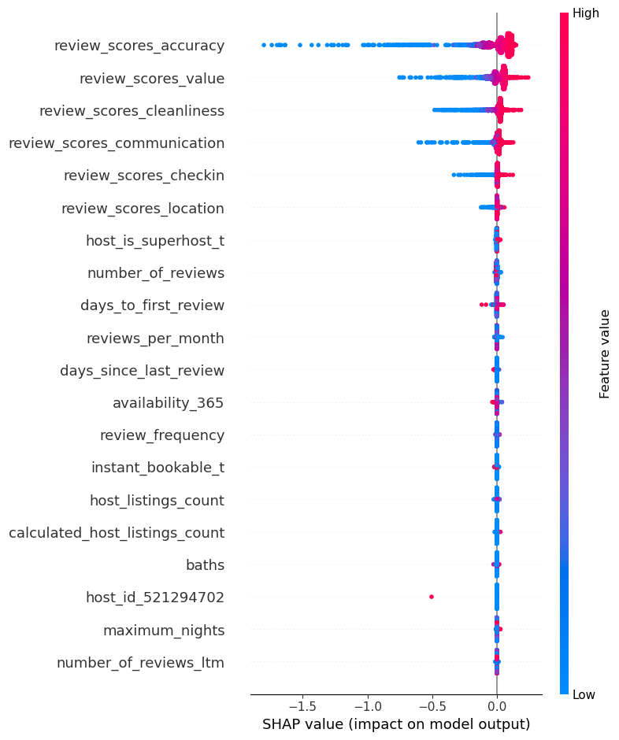

```python
shap.summary_plot(train_rf_shap_values, X_train_enc)
plt.figure(figsize=(0.5, 0.05))
```

The SHAP dependence plot provides a closer view of individual features. Similarly to above, we can see that the `review_scores_accuracy` feature seems to be positively correlated with the prediction outcome; as `review_scores_accuracy` increases, the model's prediction increases as well. This plot also shows a bit of clustering towards the top right, which indicates that higher `review_scores_accuracy` values have a stronger impact on predictions as well.

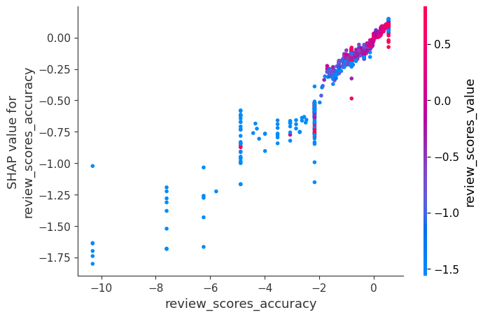

```python
shap.dependence_plot("review_scores_accuracy", train_rf_shap_values, X_train_enc)
plt.figure(figsize=(6, 4))
```

## 12. Results on the test set

By default, sci-kit's score function for Regression problems calculates $R^2$. Since I have been using RMSE as my main metric, I defined a custom scorer to help us put the final results in perspective with the other models from before.

```python
def rmse_scorer(y_preds, y_actual):
    """
    A custom scorer that calculates the RMSE scores from a model's predictions for test examples
    and the actual targets
    """
    rmse = mean_squared_error(y_actual, y_preds, squared=False)
    return -rmse
```

```python
train_preds = best_pipe_rf.predict(X_train)
```

```
X does not have valid feature names, but RandomForestRegressor was fitted with feature names
```

```python
rmse_values = rmse_scorer(train_preds, y_train)
average_rmse = np.mean(rmse_values)

print("RMSE score:", average_rmse)
```

```
RMSE score: -0.08685731189523654
```

```python
final_train_score = best_pipe_rf.score(X_train, y_train)

print("R^2 score:", final_train_score)
```

```
R^2 score: 0.9493639749806082
```

```
X does not have valid feature names, but RandomForestRegressor was fitted with feature names
```

The model looks pretty good on the train data, but how well does it generalize?

```python
preprocessor.transform(X_test)
test_preds = best_pipe_rf.predict(X_test)
```

```
X does not have valid feature names, but RandomForestRegressor was fitted with feature names
```

```python
rmse_values = rmse_scorer(test_preds, y_test)
average_rmse = np.mean(rmse_values)

print("RMSE score:", average_rmse)
```

```
RMSE score: -0.12640112734684
```

```python
final_test_score = best_pipe_rf.score(X_test, y_test)

print("R^2 score:", final_test_score)
```

```
R^2 score: 0.8376261365514781
```

```
X does not have valid feature names, but RandomForestRegressor was fitted with feature names
```

The train set achieved an RMSE score of -0.08685731189523654 and an $R^2$ score of 0.9493639749806082, and the validation set achieved an RMSE score of -0.12640112734684 and an $R^2$ score of 0.8376261365514781. While the model's performance dropped under both metrics on the test set, it seems to have performed more consistently in terms of RMSE scores. The larger gap in the $R^2$ scores suggests there is more potential to be done to lower the amount of overfitting that is occurring.

For fun, let's examine a random test point to see how different features are influencing the prediction results.

```python
X_test_enc = pd.DataFrame(
    preprocessor.transform(X_test), index=X_test.index, columns=feature_names
)
```

```python
train_rf_shap_values = rf_explainer.shap_values(X_test_enc)
train_rf_shap_values.shape
```

```
(1461, 6194)
```

```python
example_1 = 1
```

This example has a predicted `review_scores_rating` of 4.76/5 stars. The pink features are pushing the score to be higher, and are offset by the blue features. This particular example is interesting because we can see that `review_scores_accuracy` is pushing the score to be lower, but it makes sense as it has a negative value in this case.

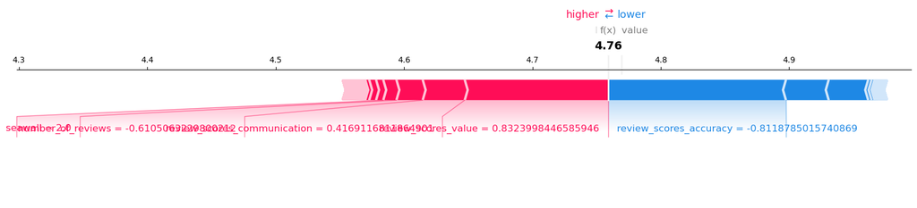

```python
shap.force_plot(
    rf_explainer.expected_value,
    train_rf_shap_values[example_1, :],
    X_test_enc.iloc[example_1, :],
    matplotlib=True,
)
```

## 13. Summary of results

**Project Goal and Model**

The goal of this project was to predict an Airbnb listing's `review_scores_rating`, as a proxy for the popularity of the listing. By creating an effective model, we could help hosts improve their listings as well as generate better algorithm recommendations for users. After testing multiple models with an assortment of parameters, we found that a random forest regressor with 22 estimators and a depth of 9 levels returned the best scores. I used RMSE as my metric of choice for this regression problem. The best model had an RMSE score of 0.12640112734684 on the test data, indicating that the standard deviation of the prediction errors (residuals) is approximately 0.1264; i.e. on average, the model's prediction of `review_scores_rating` would be off by ~0.1264. Not too bad!

**Important Features**

Although with marginal scores, many specific hosts made it on the list of top 50 feature importances too. By conducting a deeper dive into the top hosts' listings, perhaps certain patterns or consistencies can be deduced (such as description word choices or level of detail). These can then be used to help other hosts tailor their listings for increased chances of visibility.

```python
host_id_importances = rf_imp_df[rf_imp_df.index.str.contains('host_id')]
host_id_importances.sort_values(by="Importance", ascending=False)
```

|  | Importance |
| --- | --- |
| host_id_546218211 | 0.002405 |
| host_id_521294702 | 0.002349 |
| host_id_503614958 | 0.001525 |
| host_id_506811481 | 0.001443 |
| host_id_510383746 | 0.001288 |
| ... | ... |
| host_id_444526436 | 0.000000 |
| host_id_43966535 | 0.000000 |
| host_id_439008332 | 0.000000 |
| host_id_438945323 | 0.000000 |
| host_id_74646703 | 0.000000 |

2495 rows × 1 columns

## Suggestions for Further Exploration

**Analyzing Raw Text Features**

In the EDA section, I generated a word cloud to visualize the top recurring words in listing descriptions. In my pipeline, I ended up extracting bag-of-words features. Given the sheer magnitude of features in the preprocessed dataset, I suspected that individual words might not provide as significant of a contribution to the model's predictions compared to the actual attributes of a listing. This seemed to prove correct, as only a few word features showed up near the end of the list of top 50 feature importances. I also noticed a lack of overlap from the words that *were* highlighted by the model and the most prominent ones in the word cloud, reminding us that the use of common terms doesn't make a description particularly better.

Given that descriptions are still a huge part of what people use to gauge whether an accommodation has the right requirements for their needs, I still think it will be a worthwhile feature to explore more in-depth. Exploring listing descriptions in tandem with search engine optimization (SEO) opportunities could unveil valuable insights into consumer preferences. By aligning key words from both consumer queries and listing descriptions, we could find hidden patterns that can be used to improve the user experience from the host-side.

**Delving Deeper in Reviews**

Although the specific reviews that each listing received were not available in this dataset, it may be interesting to obtain and explore the content of reviews in a future project. Those results could be used to support the findings of this project by showing hosts what causes users to leave good reviews vs bad ones. While hosts will get their own individual feedback when guests they've housed leave reviews, this sort of project could help hosts learn what they can do proactively to increase their chances of receiving positive and high reviews.